# Excercises for Day One materials

Akos Mate

2019 July

In this document you’ll find some excercises that you can practice your newly acquired R knowledge. The solutions can be accessed if you check the `.rmd` source file. (you really should try solving them alone)

You can see the source files for the notebooks in the course repository: https://github.com/aakosm/R_Basics_ECPR

If you have any problems or questions regarding the excercises we can go over them on Saturday morning in the class. My advice: don’t be afraid to break things, try multiple approaches and think of it as the beggining of the journey. If something is hard at first try, don’t fixate on it, move on and then return to the problem later.

The packages needed for the solutions are:

- `readr` (optional)
- `dplyr`
- `tidyr`
- `ggplot2`

# 1 Session 1

## 1.1 Excercise 1 - using logical values

> We want to know the proportion of values in the vector `num` that are above the value of `8`. Use the functions that we have already discussed in the session to calculate this.

```r
num <- c(5, 10, 15, 20)
```

The solution looks like this:

```
#> [1] 0.75
```

## 1.2 Excercise 2 - creating data frames

> Reproduce the `df` dataframe. Hint: create each variable, then put them together into the data frame object. Pay attention to match the variable types as well (country is character, continent is factor)!

The dataframe to be reproduced: (you can give it any name you like)

```r
df
```

| country | pop | continent |
| --- | --- | --- |
| Thailand | 68.7 | Asia |
| Norway | 5.2 | Europe |
| North Korea | 24.0 | Asia |
| Canada | 47.8 | North America |
| Slovenia | 2.0 | Europe |
| France | 63.6 | Europe |
| Venezuela | 31.6 | South America |

# 2 Session 2

## 2.1 Excercise 3 - Using `ggplot2`

Load the gapminder data into the memory.

```r
library(gapminder)

gapminder_df <- gapminder
```

> Plot the distribution of the life expectancy variable (lifeExp) from the gapminder dataset. Use the `labs()` argument to set a meaningful label for the x axis, and set a title for the plot. Experiment with different `binwidth` values!

The result should look something like this:

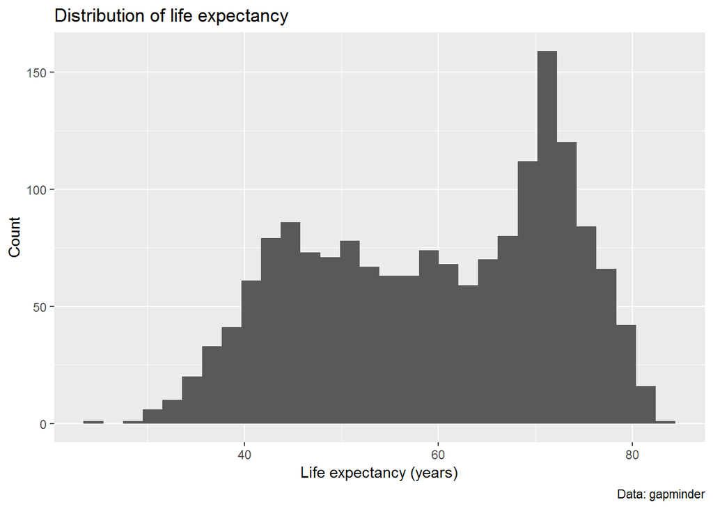

# 3 Session 3

## 3.1 Excercise 4 - Reshaping data

> 1. load a data set on financial data of Microsoft and Tesla from the `03_data_wrangling1\data` folder from the file `stock_data.csv`.
> 2. The dataset contains 3 columns: a date and closing prices for Tesla and Microsoft shares.
> 3. Use the `gather()` function to create a new data frame, with 3 variables: date, company and stock_closing. You should see something similar than below.

```r
head(stock_tidy)
```

| date | company | stock_closing |
| --- | --- | --- |
| 2016-01-11 | TSLA.Close | 207.85 |
| 2016-01-12 | TSLA.Close | 209.97 |
| 2016-01-13 | TSLA.Close | 200.31 |
| 2016-01-14 | TSLA.Close | 206.18 |
| 2016-01-15 | TSLA.Close | 204.99 |
| 2016-01-19 | TSLA.Close | 204.72 |

> 4. As a refresher, use the `group_by()` and `summarise()` functions to see the minimum, maximum and mean closing prices for the two company. Use the `%>%` pipe operator! You should get something similar as below.

The desired output:

| company | min | max | mean |
| --- | --- | --- | --- |
| MSFT.Close | 48.43 | 88.28 | 63.98619 |
| TSLA.Close | 143.67 | 385.00 | 263.09780 |

> 5. Finally, use `ggplot2` to visualise the closing prices of the two company. Use the `geom_line()`! You should get a similar plot as below.

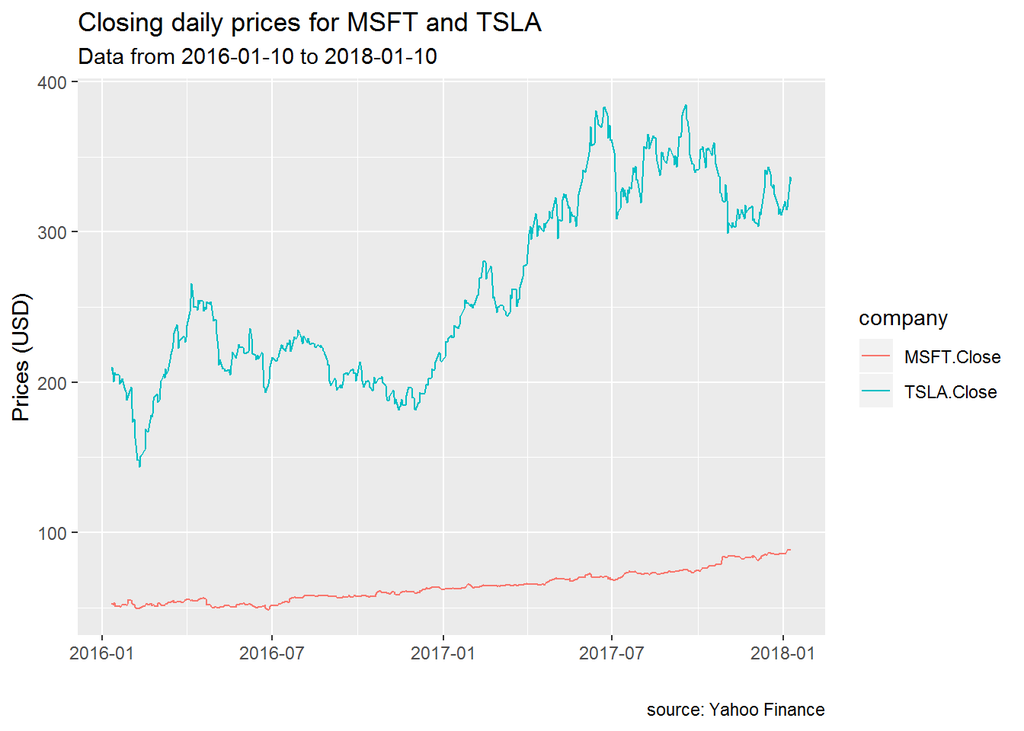

## 3.2 Excercise 5 - Appending data

> 1. load additional data from `03_data_wrangling1\data` folder’s `stock_data2.csv` file and perform the same reshaping with the `gather()` function as during our session.
> 2. then use `bind_rows()` to add the two new company to the previous `stock_tidy` data frame, by creating a new data frame, called `stock_tidy2`.
> 3. Use the %>% to pipe together your steps. Bonus: You can use the `unique()` function to check how many unique value you have in a given column.

The output looks like this:

| date | company | stock_closing |
| --- | --- | --- |
| 2016-01-11 | AAPL.Close | 98.53 |
| 2016-01-12 | AAPL.Close | 99.96 |
| 2016-01-13 | AAPL.Close | 97.39 |
| 2016-01-14 | AAPL.Close | 99.52 |
| 2016-01-15 | AAPL.Close | 97.13 |

Unique companies in the dataset:

```
#> [1] "AAPL.Close" "F.Close"    "TSLA.Close" "MSFT.Close"
```

# 4 Session 4

## 4.1 Excercise 6 - The `%>%` operator

> Replicate the following code below *without* using the pipe (%>%) operator!

```r
library(dplyr)
library(titanic)

titanic_df <- as.data.frame(Titanic)

titanic_df_new <- titanic_df %>%
  filter(Survived == "Yes") %>%
  mutate(Class = recode(Class, "1st" = 1, "2nd" = 2, "3rd" = 3, "Crew" = 0)) %>%
  mutate(Adult = recode(Age, "Child" = 0, "Adult" = 1)) %>%
  select(-Age) %>%
  filter(Sex == "Female", Adult == 1)
```

> Produce the same output as the code below *with* using the pipe (%>%) operator!

```r
data(ToothGrowth) # result from an experiment studying the effect of vitamin C on tooth growth in 60 Guinea pigs

toothgrowth_df <- as.data.frame(ToothGrowth)

toothgrowth_df <- rename(toothgrowth_df, toothLenghth = len)
toothgrowth_df <- rename(toothgrowth_df, supplementType = supp)
toothgrowth_df <- filter(toothgrowth_df, between(toothLenghth, 10, 25.5))
toothgrowth_df <- arrange(toothgrowth_df, dose)
toothgrowth_df <- mutate(toothgrowth_df, dose_mcg = dose*1000) # converting milligrams to micrograms
```

## 4.2 Excercise 7 - Data wrangiling with `dplyr`

Use the `iris` dataset for this excercise.

```r
iris_df <- iris
```

> 1. check your data, what are the variables, how many observations do we have and what types?

```
#> Observations: 150
#> Variables: 5
#> $ Sepal.Length <dbl> 5.1, 4.9, 4.7, 4.6, 5.0, 5.4, 4.6, 5.0, 4.4, 4.9,...
#> $ Sepal.Width  <dbl> 3.5, 3.0, 3.2, 3.1, 3.6, 3.9, 3.4, 3.4, 2.9, 3.1,...
#> $ Petal.Length <dbl> 1.4, 1.4, 1.3, 1.5, 1.4, 1.7, 1.4, 1.5, 1.4, 1.5,...
#> $ Petal.Width  <dbl> 0.2, 0.2, 0.2, 0.2, 0.2, 0.4, 0.3, 0.2, 0.2, 0.1,...
#> $ Species      <fct> setosa, setosa, setosa, setosa, setosa, setosa, s...
```

> 2. how does the distribution of the variables look like?

Example output with petal lenght.

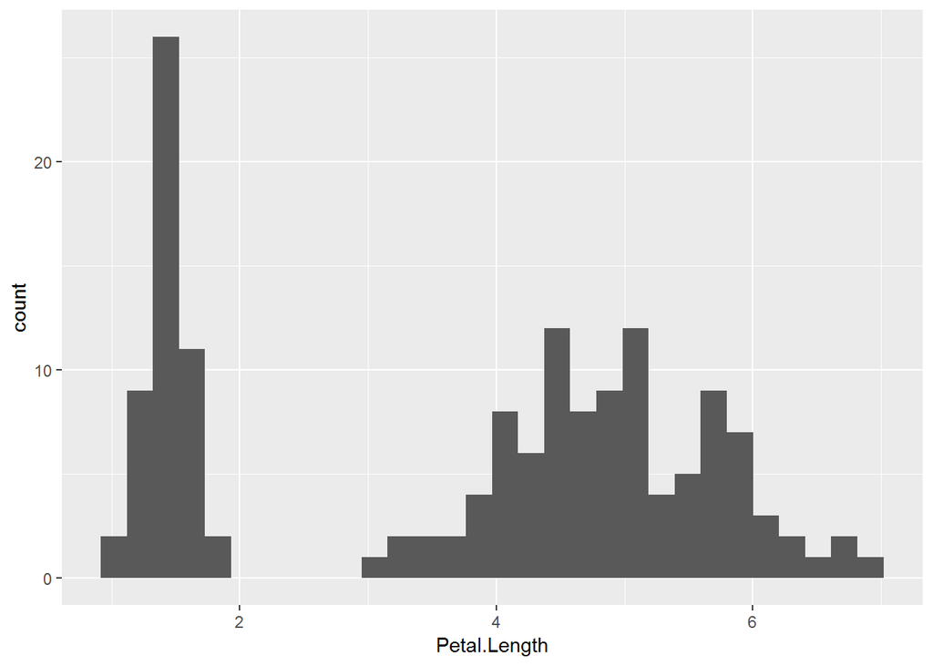

> 3. create a summary table, with the standard deviation of Petal lenght (use the `sd()`), grouped by every species.

| Species | std.dev |
| --- | --- |
| setosa | 0.1736640 |
| versicolor | 0.4699110 |
| virginica | 0.5518947 |

> 4. Select all the variables that start with “Sepal” and put them into the `iris_sepal` object.

```r
head(iris_sepal)
```

|  | Sepal.Length | Sepal.Width |
| --- | --- | --- |
| 1 | 5.1 | 3.5 |
| 2 | 4.9 | 3.0 |
| 3 | 4.7 | 3.2 |
| 4 | 4.6 | 3.1 |
| 5 | 5.0 | 3.6 |
| 6 | 5.4 | 3.9 |

> 5. Create a scatter plot that shows the association between the sepal attributes. The points should be colored by species.

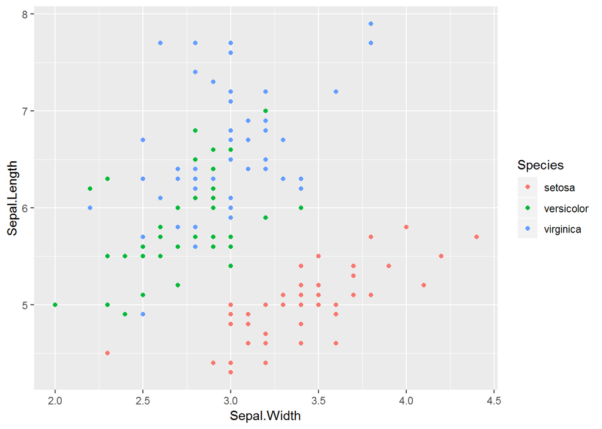

## 4.3 Excercise 8 - Joining various datasets

> Excercise:  
> (1) install and load the `nycflights13` package (2) load the `flights` and `airlines` data frames into the environment

```r
library(nycflights13)
flights_df <- flights
airlines_df <- airlines
```

> 3. check the variables in both data frames and search potential key(s). (hint: you can extract variable names with `names()` and use the `match()` function on them)
> 4. perform a left join on the data frames using the key.

After the join, the new dataset should look like this:

```r
head(new_df)
```

| year | month | day | dep_time | sched_dep_time | dep_delay | arr_time | sched_arr_time | arr_delay | carrier | flight | tailnum | origin | dest | air_time | distance | hour | minute | time_hour | name |
| --- | --- | --- | --- | --- | --- | --- | --- | --- | --- | --- | --- | --- | --- | --- | --- | --- | --- | --- | --- |
| 2013 | 1 | 1 | 517 | 515 | 2 | 830 | 819 | 11 | UA | 1545 | N14228 | EWR | IAH | 227 | 1400 | 5 | 15 | 2013-01-01 05:00:00 | United Air Lines Inc. |
| 2013 | 1 | 1 | 533 | 529 | 4 | 850 | 830 | 20 | UA | 1714 | N24211 | LGA | IAH | 227 | 1416 | 5 | 29 | 2013-01-01 05:00:00 | United Air Lines Inc. |
| 2013 | 1 | 1 | 542 | 540 | 2 | 923 | 850 | 33 | AA | 1141 | N619AA | JFK | MIA | 160 | 1089 | 5 | 40 | 2013-01-01 05:00:00 | American Airlines Inc. |
| 2013 | 1 | 1 | 544 | 545 | -1 | 1004 | 1022 | -18 | B6 | 725 | N804JB | JFK | BQN | 183 | 1576 | 5 | 45 | 2013-01-01 05:00:00 | JetBlue Airways |
| 2013 | 1 | 1 | 554 | 600 | -6 | 812 | 837 | -25 | DL | 461 | N668DN | LGA | ATL | 116 | 762 | 6 | 0 | 2013-01-01 06:00:00 | Delta Air Lines Inc. |
| 2013 | 1 | 1 | 554 | 558 | -4 | 740 | 728 | 12 | UA | 1696 | N39463 | EWR | ORD | 150 | 719 | 5 | 58 | 2013-01-01 05:00:00 | United Air Lines Inc. |